# Assessment_Part1

```r
library(tidyverse)
LondonData <- read_csv("https://files.datapress.com/london/dataset/ward-profiles-and-atlas/2015-09-24T14:21:24/ward-profiles-excel-version.csv", na = "n/a")
```

```r
LondonData <- data.frame(LondonData)
LondonBoroughs <- LondonData[grep("^E09",LondonData[,3]),]

library(maptools)
library(RColorBrewer)
library(classInt)
library(OpenStreetMap)
library(sp)
library(rgeos)
library(tmap)
library(tmaptools)
library(sf)
library(rgdal)
library(geojsonio)
EW <- geojson_read("http://geoportal.statistics.gov.uk/datasets/8edafbe3276d4b56aec60991cbddda50_2.geojson", what = "sp")
LondonMap <- EW[grep("^E09",EW@data$lad15cd),]

BoroughMapSF <- read_shape("N:\\GIS\\WK1\\BoundaryData\\england_lad_2011.shp", as.sf = TRUE)
BoroughMapSP <- LondonMap

BoroughDataMap <- append_data(BoroughMapSF,LondonData, key.shp = "code", key.data = "New.code", ignore.duplicates = TRUE)
```

```
## Data contains duplicated keys: E09000001
```

```
## Over coverage: 626 out of 659 data records were not appended. Run over_coverage() to get the corresponding data row numbers and key values.
```

```r
library(tmap)
library(tmaptools)
tmap_mode("plot")
```

```
## tmap mode set to plotting
```

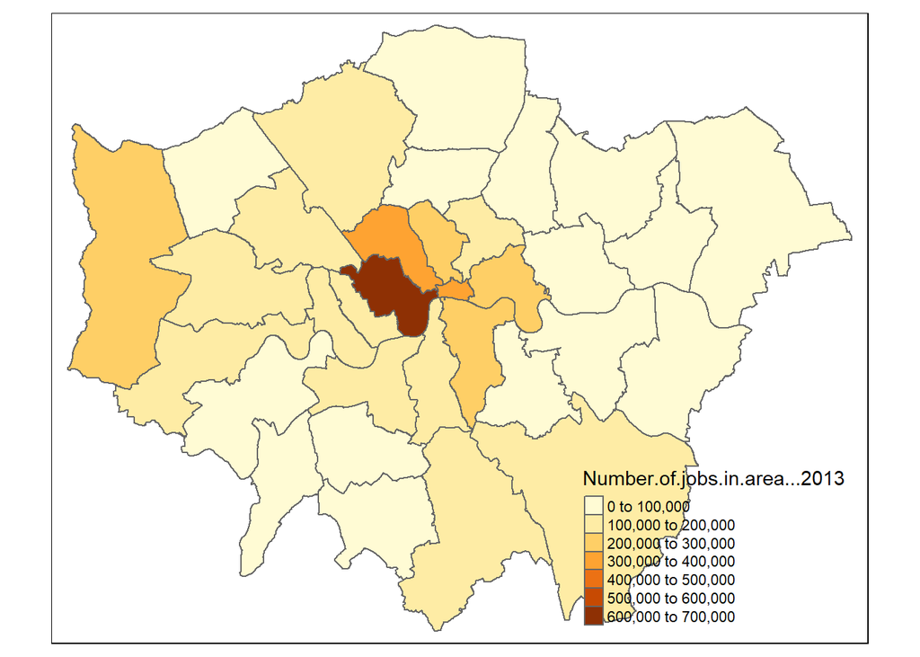

```r
qtm(BoroughDataMap, fill = "Number.of.jobs.in.area...2013")
```

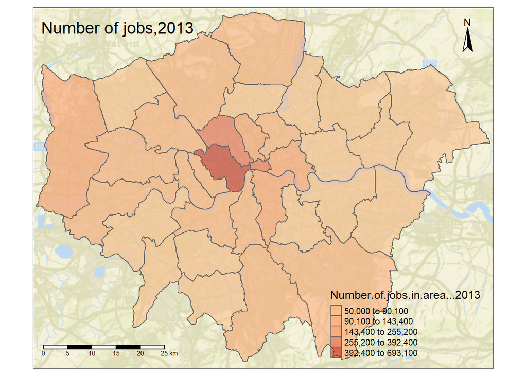

```r
london_osm <- read_osm(BoroughDataMap, type = "esri", zoom = NULL)
qtm(london_osm) +
  tm_shape(BoroughDataMap) +
  tm_polygons("Number.of.jobs.in.area...2013",
              style="jenks",
              palette="OrRd",
              midpoint=NA,
              alpha = 0.5) +
  tm_compass(position = c("right", "top"),type = "arrow") +
  tm_scale_bar(position = c("left", "bottom")) +
  tm_layout(title = "Number of jobs,2013", legend.position = c("right", "bottom"))
```

To start with, to better compare the different two ways to generate maps using GUI and Command line separately, I chose the same data sources for both maps. There are two main data sources being used. Firstly, there is a Shapefile including boundaries for the 32 London Boroughs plus the City of London, which can be downloaded from the Edina Census Geography website, a reliable UK Data Service geography service providing numerous datasets besides boundaries. Secondly, an excel file called ward-profiles-excel-version.xls for London Ward Profile and Atlas was downloaded from The London Datastore, which provides sufficiently up-to-date census data as well as some spatial data. Thus, I use these two data sources to analyze the total number of jobs in 2013. Then, I chose ArcMap for GUI and R for Command line software. On the one hand, ArcMap focuses on the graphical representation, thus being more visualized and intuitive, especially for novice. With the clear menu, toolbars and recognizable icons in interface, GUI enables the users to select commands and implement functions easily via a mouse, and even when forget the precise location of some tools, users can use the search windows. However, the intuitive graphical interface is all you can get, which means GUI cannot include all commands except the windows and menus you see. Moreover, it is inefficient to use GUI while running multiple commands, as frequently clicking the mouse is a waste of time. On the other hand, Command-line interface, which focuses on batch processing with text mode, can deal with combination of tools, therefore being high-efficient and highly automated. Moreover, users also can select and summarize data, rename specific values, and install plenty useful packages for invoking. Therefore, Command-line interface provides users a way directly to the information they want without executing multiple commands step-by-step, all operations can be done quickly using the keyboard. Nevertheless, it is difficult to remember various tools and complex commands; therefore, R is not as user-friendly as GUI in general.

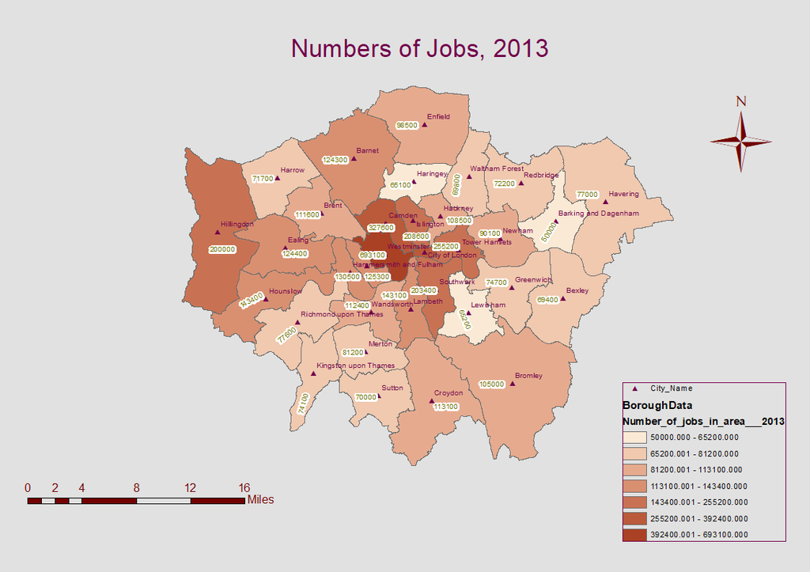

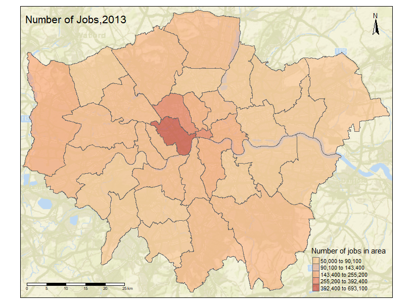

Using the same data sources, two maps I generated are similar in general, both have basic elements, including the title, legend, compass and scale bar. It is showed that most of job opportunities concentrated on the central region with the deepest color. However, the city names and the number of jobs for each borough are clear in map made by ArcMap. In addition, there are two more classifications of color, making this map brightly colored. Nevertheless, the OpenStreetMap package installed in R makes the background pattern of generated map more vivid. In details, to generate map using ArcMap, the workflow is as follows: Connected to my folder > Create a new file geodatabase > Set up ArcMap workspace > Add the shapefile and excel file > Join the common values in excel to shapefile using code > Open layer properties > Click Quantiles and Graduated colors > Select the value for ‘Number_of_Jobs_in_area___2013’ > Choose the color ramp and set seven classes with Natural Breaks > Add legend, scale bar, title and north arrow > Add the city names and specific data for each borough > Move to layout view and export map. Moreover, the workflow for R is as follows: Library packages will be used > Read data csv file and use data.frame > Read shapefile > append csv data to shapefile using code > Set the OpenStreetMap as the background > Use tm_shape function, type the style and color, and add compass, scale bar, legend and title > Export map.